# C50_text

## Author attribution

In this part, I will clean the text data, transform as TF-IDF, and construct two models with the first 100 principle components.

#### Import and cleaning:

When importing the document, doc_list is a list of authors.  
Please note that saving any other file under directory of C50train can lead to an importing bug.

```r
library(tm)
library(magrittr)
library(slam)
library(proxy)
library(glmnet)
```

```r
readerPlain = function(fname){
  readPlain(elem=list(content=readLines(fname)),
            id=fname, language='en') }
setwd("/Users/k.vincent/STA380/data/ReutersC50/C50train")
doc_list = Sys.glob('*')
file_list = Sys.glob(paste0(doc_list, '/*.txt'))

file_list = Sys.glob(paste0(doc_list, '/*.txt'))
temp = lapply(file_list, readerPlain)


mynames = file_list %>%
{ strsplit(., '/', fixed=TRUE) } %>%
{ lapply(., tail, n=2) } %>%
{ lapply(., paste0, collapse = '') } %>%
  unlist
names(temp) = mynames


documents_raw = VCorpus(VectorSource(temp))

my_documents = documents_raw
my_documents = tm_map(my_documents, content_transformer(tolower))
my_documents = tm_map(my_documents, content_transformer(removeNumbers))
my_documents = tm_map(my_documents, content_transformer(removePunctuation))
my_documents = tm_map(my_documents, content_transformer(stripWhitespace))

DTM = DocumentTermMatrix(my_documents)

DTM = removeSparseTerms(DTM, 0.95)
#Orignal Sparsity is over 90%. To decrease, remove terms that never show up in 95% or more articles.

# construct TF IDF weights
tfidf = weightTfIdf(DTM)
```

For the document cleaning, I DID NOT exclude any stopwords. As IDF will take term frequency accross articles into account, a common but meaningless word tends to have lower TF-IDF. Thus, I’ll let the TF-IDF calculation to do the work.

#### PCA of the training data

```r
# Now PCA on tfidf
X = as.matrix(tfidf)
summary(colSums(X))
```

```
##    Min. 1st Qu.  Median    Mean 3rd Qu.    Max.
##   0.000   3.212   4.356   4.899   5.891  20.616
```

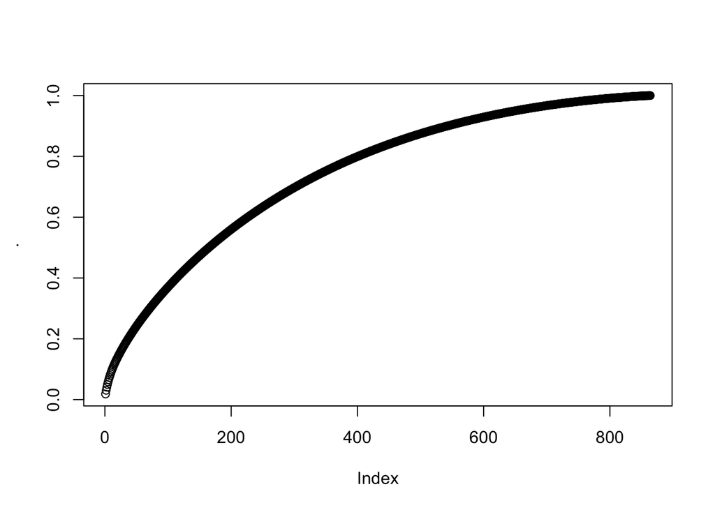

```r
scrub_cols = which(colSums(X) == 0)
X = X[,-scrub_cols]

pca= prcomp(X, scale=TRUE)
summary(pca)$importance[3,]%>%plot()
```

```r
#independent variables: X
X = pca$x[,1:100]

all  <- vector()
i = 1
for (auther in doc_list){
  all[i] = auther
  i = i+1
}

#Model dependent variable: Y
Y = vector()
for( i in 1:2500){
  Y[i] = all[ceiling(i/50)]
}
```

The increasing rate of cumulative explained variance decreases gradually with the number of PCs.  
Considering a balance between variable number and explained variance, I pick up the top 100 PCs, with which 37% variance are explained, to build the model.

#### Test set import and clean

likewisely to the process of train set.

```r
readerPlain = function(fname){
  readPlain(elem=list(content=readLines(fname)),
            id=fname, language='en') }
setwd("/Users/k.vincent/STA380/data/ReutersC50/C50test")
doc_list = Sys.glob('*')
file_list = Sys.glob(paste0(doc_list, '/*.txt'))


file_list = Sys.glob(paste0(doc_list, '/*.txt'))
cp2 = lapply(file_list, readerPlain)


mynames = file_list %>%
{ strsplit(., '/', fixed=TRUE) } %>%
{ lapply(., tail, n=2) } %>%
{ lapply(., paste0, collapse = '') } %>%
  unlist
names(cp2) = mynames


documents_raw_1 = VCorpus(VectorSource(cp2))

my_documents1 = documents_raw_1
my_documents1 = tm_map(my_documents1, content_transformer(tolower)) # make everything lowercase
my_documents1 = tm_map(my_documents1, content_transformer(removeNumbers)) # remove numbers
my_documents1 = tm_map(my_documents1, content_transformer(removePunctuation)) # remove punctuation
my_documents1 = tm_map(my_documents1, content_transformer(stripWhitespace)) ## remove excess white-space

DTM_test = DocumentTermMatrix(my_documents1,control = list(dictionary=Terms(DTM)))
DTM_test = removeSparseTerms(DTM_test, 0.95)

tfidf_test = weightTfIdf(DTM_test)

X_test = as.matrix(tfidf_test)
scrub_cols = which(colSums(X_test) == 0)
X_test = X_test[,-scrub_cols]
```

Now, X_test is our TF-IDF of the test file. As our model will be based on the 100 PCs of training set, we need to calculate the linear combination of the test set TF-IDF with the loadings of 100 PCs of trainings set before making prediction.

```r
####Matching the column name of test TFIDF to the Train TFIDF
train_pre_pc = as.matrix(tfidf)
scrub_cols = which(colSums(train_pre_pc) == 0)
train_pre_pc = train_pre_pc[,-scrub_cols]

train_name = colnames(train_pre_pc)
test_name = colnames(X_test)
sup = setdiff(train_name, test_name)

temp_x = data.frame(X_test)
for (colname_ in sup){
  temp_x[,colname_] = 0
}

##somehow there is still difference
#This can be identified using:
#setdiff(colnames(t), train_name)

#hereby I manually fix them
colnames(temp_x)[colnames(temp_x)=="for."] <- "for"
colnames(temp_x)[colnames(temp_x)=="next."] <- "next"
colnames(temp_x)[colnames(temp_x)=="while."] <- "while"
t = data.matrix(temp_x)
t <- t[, order(colnames(t))]
#####

#transform the test set to the principal component spaces of the training set
test.data <- predict(pca, newdata =t)
test.data <- as.data.frame(test.data)
test.data <- test.data[,1:100]
```

test.data is the X of test_set for our model to predict.

#### Model: Logistics LASSO

```r
library(MLmetrics)
library(caret)
out1 = glmnet(X, factor(Y), family="multinomial")
p1 = predict(out1, data.matrix(test.data), s=0.01, type = "response")

myPredict_for_out1 <- function(which_article){
  return(which.max(p1[which_article,,]))
}

Ya  <- vector()
i = 1
for (auther in doc_list){
  Ya[i] = auther
  i = i+1
}

#real is the true values
real = vector()
for( i in 1:2500){
  real[i] = Ya[ceiling(i/50)]
}

#aut is our prediction
aut = vector()
for (i in 1:2500){
  aut[i] =names(myPredict_for_out1(i))
}

Accuracy(aut, real)
```

```
## [1] 0.416
```

```r
(table(aut,real)%>%confusionMatrix)$byClass[,"Balanced Accuracy"]
```

```
##     Class: AaronPressman        Class: AlanCrosby    Class: AlexanderSmith
##                0.8646939                0.6275510                0.7381633
##   Class: BenjaminKangLim     Class: BernardHickey       Class: BradDorfman
##                0.6642857                0.5804082                0.5848980
##  Class: DarrenSchuettler       Class: DavidLawder     Class: EdnaFernandes
##                0.6559184                0.5442857                0.5379592
##       Class: EricAuchard    Class: FumikoFujisaki    Class: GrahamEarnshaw
##                0.5838776                0.9234694                0.8342857
##  Class: HeatherScoffield     Class: JaneMacartney        Class: JanLopatka
##                0.6414286                0.5079592                0.6738776
##      Class: JimGilchrist          Class: JoeOrtiz      Class: JohnMastrini
##                0.8969388                0.5385714                0.6646939
##      Class: JonathanBirt    Class: JoWinterbottom       Class: KarlPenhaul
##                0.7410204                0.8328571                0.8065306
##         Class: KeithWeir    Class: KevinDrawbaugh     Class: KevinMorrison
##                0.6473469                0.6020408                0.5973469
##     Class: KirstinRidley Class: KouroshKarimkhany         Class: LydiaZajc
##                0.6871429                0.8185714                0.8087755
##    Class: LynneO'Donnell   Class: LynnleyBrowning   Class: MarcelMichelson
##                0.8826531                0.9434694                0.7746939
##      Class: MarkBendeich        Class: MartinWolk      Class: MatthewBunce
##                0.7132653                0.5461224                0.9053061
##     Class: MichaelConnor        Class: MureDickie         Class: NickLouth
##                0.7442857                0.7285714                0.8212245
##   Class: PatriciaCommins     Class: PeterHumphrey        Class: PierreTran
##                0.6161224                0.8557143                0.6955102
##        Class: RobinSidel      Class: RogerFillion       Class: SamuelPerry
##                0.9026531                0.8065306                0.6055102
##      Class: SarahDavison       Class: ScottHillis       Class: SimonCowell
##                0.6883673                0.5195918                0.6057143
##          Class: TanEeLyn    Class: TheresePoletti        Class: TimFarrand
##                0.5634694                0.6202041                0.7871429
##        Class: ToddNissen      Class: WilliamKazer
##                0.6620408                0.5089796
```

Out-of-sample overall accuracy is around 41%. The baseline in this prediction is 1/50, which is 2%. To improve the accuracy, one may cross validate on LASSO lambda. Due to limited computation ability, current lambda is only based on manual adjustment.  
“Balanced Accuracy = (sensitivity+specificity)/2”  
Though the overall accuracy is only 41%, the model performs well in term of Sensitivity and Specificity, according to the balanced accuracy(50%~90%). That is, the proportion of actual positives/negatives that are correctly identified is high.

#### Model: Random Forest

```r
library(randomForest)
fY = factor(Y)
dfX =data.frame(X)
XY = cbind(dfX, fY)

rffit = randomForest(fY~.,data=XY,ntree=500)
prf<- predict(rffit, newdata = test.data)
Accuracy(prf, factor(real))
```

```
## [1] 0.5136
```

```r
(table(prf,real)%>%confusionMatrix)$byClass[,"Balanced Accuracy"]
```

```
##     Class: AaronPressman        Class: AlanCrosby    Class: AlexanderSmith
##                0.8585714                0.7393878                0.7665306
##   Class: BenjaminKangLim     Class: BernardHickey       Class: BradDorfman
##                0.6134694                0.6883673                0.7616327
##  Class: DarrenSchuettler       Class: DavidLawder     Class: EdnaFernandes
##                0.6175510                0.5379592                0.5777551
##       Class: EricAuchard    Class: FumikoFujisaki    Class: GrahamEarnshaw
##                0.6555102                0.8963265                0.8755102
##  Class: HeatherScoffield     Class: JaneMacartney        Class: JanLopatka
##                0.6530612                0.6283673                0.7071429
##      Class: JimGilchrist          Class: JoeOrtiz      Class: JohnMastrini
##                0.9573469                0.6618367                0.7336735
##      Class: JonathanBirt    Class: JoWinterbottom       Class: KarlPenhaul
##                0.7936735                0.8277551                0.9214286
##         Class: KeithWeir    Class: KevinDrawbaugh     Class: KevinMorrison
##                0.8444898                0.7381633                0.7824490
##     Class: KirstinRidley Class: KouroshKarimkhany         Class: LydiaZajc
##                0.7679592                0.8373469                0.8100000
##    Class: LynneO'Donnell   Class: LynnleyBrowning   Class: MarcelMichelson
##                0.8873469                0.9497959                0.7167347
##      Class: MarkBendeich        Class: MartinWolk      Class: MatthewBunce
##                0.6979592                0.6775510                0.8981633
##     Class: MichaelConnor        Class: MureDickie         Class: NickLouth
##                0.7977551                0.6230612                0.8240816
##   Class: PatriciaCommins     Class: PeterHumphrey        Class: PierreTran
##                0.6759184                0.8981633                0.7751020
##        Class: RobinSidel      Class: RogerFillion       Class: SamuelPerry
##                0.8471429                0.8071429                0.7010204
##      Class: SarahDavison       Class: ScottHillis       Class: SimonCowell
##                0.7246939                0.5644898                0.7453061
##          Class: TanEeLyn    Class: TheresePoletti        Class: TimFarrand
##                0.6189796                0.7357143                0.7924490
##        Class: ToddNissen      Class: WilliamKazer
##                0.7840816                0.5959184
```

Out-of-sample overall accuracy is around 51%, with a similar balanced accuracy of each class. Specifically, both of the models have difficulies to identify ScottHillis, EdnaFernandes and WilliamKazer (balanced accuracy <60%).  
Acheiving a significantly higher overall accuracy, random forest is preferable to LASSO.

#### So, are there any sets of authors whose articles seem difficult to distinguish from one another?

```r
cosine_docs = function(dtm) {
  crossprod_simple_triplet_matrix(t(dtm))/(sqrt(col_sums(t(dtm)^2) %*% t(col_sums(t(dtm)^2))))
}

# use the function to compute pairwise cosine similarity for all documents
cosine_mat = cosine_docs(tfidf)

myStore = data.frame()
for(i in 1:2500){
  myStore[i,1] = as.numeric(i)
  myStore[i,2] = as.numeric(sort(cosine_mat[i,], decreasing=F)[1]%>%names)
  myStore[i,3] = sort(cosine_mat[i,], decreasing=F)[1]
}
colnames(myStore)<- c("Article_1", "Article_2", "Cosine_Distance")

#These are the articles who are very similar to each other
myrank = myStore[order(myStore$Cosine_Distance),]
#drop reversed duplicates
temp1 = apply(myrank[,1:2],1,function(x) paste(sort(x),collapse=''))
#These are the articles who are very similar, even identical, to each other
(myrank[!duplicated(gsub(" ", "", temp1, fixed = TRUE)),])[1:10,]
```

```
##      Article_1 Article_2 Cosine_Distance
## 6            6       615    0.000000e+00
## 764        764         6    0.000000e+00
## 765        765         6    0.000000e+00
## 1206      1206      1681    0.000000e+00
## 2187      2187      1681    0.000000e+00
## 800        800      2393    2.792552e-08
## 212        212       765    1.206647e-07
## 1513      1513       615    1.921827e-07
## 602        602      2393    2.364743e-07
## 780        780       615    2.912278e-07
```

```r
#These are the corresponding authers
myrank1 = myrank[!duplicated(gsub(" ", "", temp1, fixed = TRUE)),]
myrank1$Article_1 = ceiling(myrank1$Article_1/50)
myrank1$Article_2 = ceiling(myrank1$Article_2/50)
myrank1 = myrank1[order(myrank1$Cosine_Distance),]


#pragma only after myrank1 defined
myThreshold<- function(threshold){
  local_df = myrank1[myrank1[,3]<threshold,]
  tr = apply(local_df[,1:2],1,function(x) paste(sort(x),collapse='-'))%>%table
  return(tr[order(tr, decreasing = TRUE)])
}

#These are the authers have lots of similar articles
myThreshold(0.001)%>%head
```

```
## .
##  1-14 16-34 16-40  1-11  1-16   1-4
##     8     7     6     5     5     5
```